# Machine Learning with Sales Records

Data 622 - Homework 1

Cliff Lee

2023-10-07

### Brief

This data set includes features for a fictitious global retail company that sells household products, presumably in stores and online. The continuous features describe financial cost and sales related metrics while the categorical features describe the company products and geographic data. Additionally, there are two time-based features regarding sales orders as well.

I noticed the data set includes a binary category feature for sales channel (offline versus online), so I decided to see if the other features could predict if a product favored a particular channel, given its sales and geographic data. Even though the data set was artificially generated, I can easily see where an operations director needs to know if more sales occurred for a given product, region and time.

Exploring the data shows a few clear indications: several of the continuous variables are collinear (greater than 0.6) and the categorical variables are well balanced with no data input errors. Also, no features had any missing data so no imputation was required. For these reasons, I chose to use the k-nearest neighbor (KNN) and naive Bayes classifier to predict the sales channel for each observation as the data set satisfies and overcomes each model’s requirements and weaknesses.

However after training each model on small (1000 records) and large data sets (10,000 records), I found the performance to be mixed at best where they didn’t predict better than 57% and even lower at 50% for the larger data set. Their respective accuracy rates are below:

| Model | Accuracy.1k.Records | Accuracy.10k.Records |
| --- | --- | --- |
| KNN | 0.57 | 0.50 |
| Naive Bayes | 0.57 | 0.49 |

### Dataset Exploration

Starting from data sets of 1000 and 10,000 records, we read the input CSV with pre-defined column types. The column labels are as follows:

```r
# Load the smaller data set with factors, numbers and character field types defined
small <- read_csv("1000 Sales Records.csv", col_types="fffffcncnnnnn")
large <- read_csv("10000 Sales Records.csv", col_types="fffffcncnnnnn")
colnames(small)
```

```
##  [1] "Region"         "Country"        "Item Type"      "Sales Channel"
##  [5] "Order Priority" "Order Date"     "Order ID"       "Ship Date"
##  [9] "Units Sold"     "Unit Price"     "Unit Cost"      "Total Revenue"
## [13] "Total Cost"     "Total Profit"
```

Judging from the labels for the continuous features, there are natural groups that instantly appear:

- Units - sold, price and cost features
- Total - revenue, cost, profit
- Date - order, ship

The only continuous feature that stands alone is the order ID as it’s presumably a meta data field assigned to identify a row and not recorded by sales.

### Data Set Summary

From the data set summary, we see no missing values for any variables. If there were, we would have to try to impute values as to not diverge from the feature medians.

```r
summary(small)
```

```
##                                Region              Country
##  Middle East and North Africa     :138   Cuba          : 11
##  North America                    : 19   Malaysia      : 10
##  Asia                             :136   Czech Republic: 10
##  Sub-Saharan Africa               :262   Zimbabwe      : 10
##  Europe                           :267   Bahrain       : 10
##  Central America and the Caribbean: 99   Fiji          :  9
##  Australia and Oceania            : 79   (Other)       :940
##            Item Type   Sales Channel Order Priority  Order Date
##  Beverages      :101   Offline:520   M:242          Length:1000
##  Vegetables     : 97   Online :480   C:262          Class :character
##  Office Supplies: 89                 H:228          Mode  :character
##  Baby Food      : 87                 L:268
##  Personal Care  : 87
##  Snacks         : 82
##  (Other)        :457
##     Order ID          Ship Date           Units Sold     Unit Price
##  Min.   :102928006   Length:1000        Min.   :  13   Min.   :  9.33
##  1st Qu.:328074026   Class :character   1st Qu.:2420   1st Qu.: 81.73
##  Median :556609714   Mode  :character   Median :5184   Median :154.06
##  Mean   :549681325                      Mean   :5054   Mean   :262.11
##  3rd Qu.:769694483                      3rd Qu.:7537   3rd Qu.:421.89
##  Max.   :995529830                      Max.   :9998   Max.   :668.27
##
##    Unit Cost      Total Revenue       Total Cost       Total Profit
##  Min.   :  6.92   Min.   :   2043   Min.   :   1417   Min.   :    532.6
##  1st Qu.: 56.67   1st Qu.: 281192   1st Qu.: 164932   1st Qu.:  98376.1
##  Median : 97.44   Median : 754939   Median : 464726   Median : 277226.0
##  Mean   :184.97   Mean   :1327322   Mean   : 936119   Mean   : 391202.6
##  3rd Qu.:263.33   3rd Qu.:1733503   3rd Qu.:1141750   3rd Qu.: 548456.8
##  Max.   :524.96   Max.   :6617210   Max.   :5204978   Max.   :1726181.4
##
```

```r
summary(large)
```

```
##                                Region               Country
##  Sub-Saharan Africa               :2603   Lithuania     :  72
##  Europe                           :2633   United Kingdom:  72
##  Middle East and North Africa     :1264   Moldova       :  71
##  Asia                             :1469   Seychelles    :  70
##  Central America and the Caribbean:1019   Croatia       :  70
##  Australia and Oceania            : 797   Montenegro    :  69
##  North America                    : 215   (Other)       :9576
##            Item Type    Sales Channel  Order Priority  Order Date
##  Personal Care  : 888   Online :5061   L:2494         Length:10000
##  Household      : 875   Offline:4939   C:2555         Class :character
##  Clothes        : 872                  H:2503         Mode  :character
##  Baby Food      : 842                  M:2448
##  Office Supplies: 837
##  Vegetables     : 836
##  (Other)        :4850
##     Order ID          Ship Date           Units Sold      Unit Price
##  Min.   :100089156   Length:10000       Min.   :    2   Min.   :  9.33
##  1st Qu.:321806669   Class :character   1st Qu.: 2531   1st Qu.:109.28
##  Median :548566305   Mode  :character   Median : 4962   Median :205.70
##  Mean   :549871874                      Mean   : 5003   Mean   :268.14
##  3rd Qu.:775998104                      3rd Qu.: 7472   3rd Qu.:437.20
##  Max.   :999934232                      Max.   :10000   Max.   :668.27
##
##    Unit Cost      Total Revenue       Total Cost       Total Profit
##  Min.   :  6.92   Min.   :    168   Min.   :    125   Min.   :     43.4
##  1st Qu.: 56.67   1st Qu.: 288551   1st Qu.: 164786   1st Qu.:  98329.1
##  Median :117.11   Median : 800051   Median : 481606   Median : 289099.0
##  Mean   :188.81   Mean   :1333355   Mean   : 938266   Mean   : 395089.3
##  3rd Qu.:364.69   3rd Qu.:1819143   3rd Qu.:1183822   3rd Qu.: 566422.7
##  Max.   :524.96   Max.   :6680027   Max.   :5241726   Max.   :1738178.4
##
```

### Exploring Qualitative Factors

For the categorical features, I assume there are no data integrity issues such as the same region, country or item appearing more than once under two different spellings due to data input errors. To confirm this, I re-encoded the alphabetized factor levels and visually checked the spellings of the two largest qualitative features: item types and countries.

#### Item type

```
## # A tibble: 12 × 2
##    `Item Type`         n
##    <fct>           <int>
##  1 Baby Food          87
##  2 Beverages         101
##  3 Cereal             79
##  4 Clothes            78
##  5 Cosmetics          75
##  6 Fruits             70
##  7 Household          77
##  8 Meat               78
##  9 Office Supplies    89
## 10 Personal Care      87
## 11 Snacks             82
## 12 Vegetables         97
```

```
## # A tibble: 12 × 2
##    `Item Type`         n
##    <fct>           <int>
##  1 Baby Food         842
##  2 Beverages         782
##  3 Cereal            825
##  4 Clothes           872
##  5 Cosmetics         834
##  6 Fruits            795
##  7 Household         875
##  8 Meat              798
##  9 Office Supplies   837
## 10 Personal Care     888
## 11 Snacks            816
## 12 Vegetables        836
```

#### Countries

No typos were found for country names, either.

```
## # A tibble: 185 × 2
##    Country                    n
##    <fct>                  <int>
##  1 Afghanistan                6
##  2 Albania                    8
##  3 Algeria                    5
##  4 Andorra                    7
##  5 Angola                     8
##  6 Antigua and Barbuda        4
##  7 Armenia                    5
##  8 Australia                  3
##  9 Austria                    6
## 10 Azerbaijan                 3
## 11 Bahrain                   10
## 12 Bangladesh                 5
## 13 Barbados                   3
## 14 Belarus                    9
## 15 Belgium                    7
## 16 Belize                     4
## 17 Benin                      8
## 18 Bhutan                     6
## 19 Bosnia and Herzegovina     4
## 20 Botswana                   3
## 21 Brunei                     3
## 22 Bulgaria                   7
## 23 Burkina Faso               4
## 24 Burundi                    6
## 25 Cambodia                   4
## # ℹ 160 more rows
```

```
## # A tibble: 185 × 2
##    Country                 n
##    <fct>               <int>
##  1 Afghanistan            59
##  2 Albania                55
##  3 Algeria                51
##  4 Andorra                52
##  5 Angola                 54
##  6 Antigua and Barbuda    49
##  7 Armenia                46
##  8 Australia              51
##  9 Austria                58
## 10 Azerbaijan             56
## # ℹ 175 more rows
```

#### Tiles

To help explore the relationship between the output sales channel variable, we compare it to item type and countries for both data sets

##### Sales Channel and Item Types

We see a contrast in counts in the left and right columns between the item types and sales channels for both data sets. The counts are higher for the larger data set.

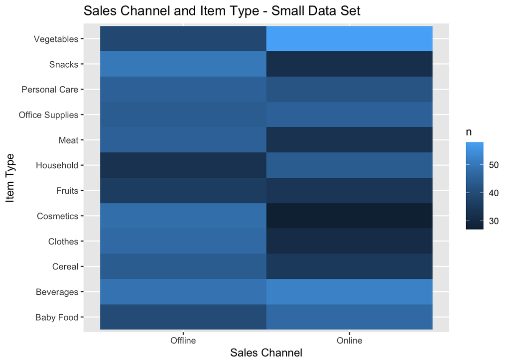

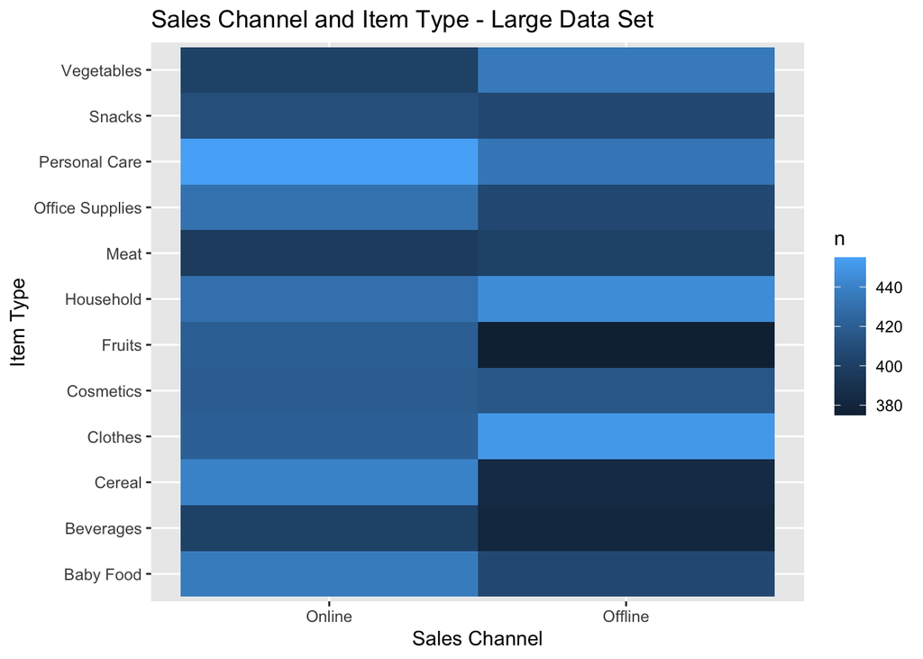

We see a similar variation in sales channel to countries, also.

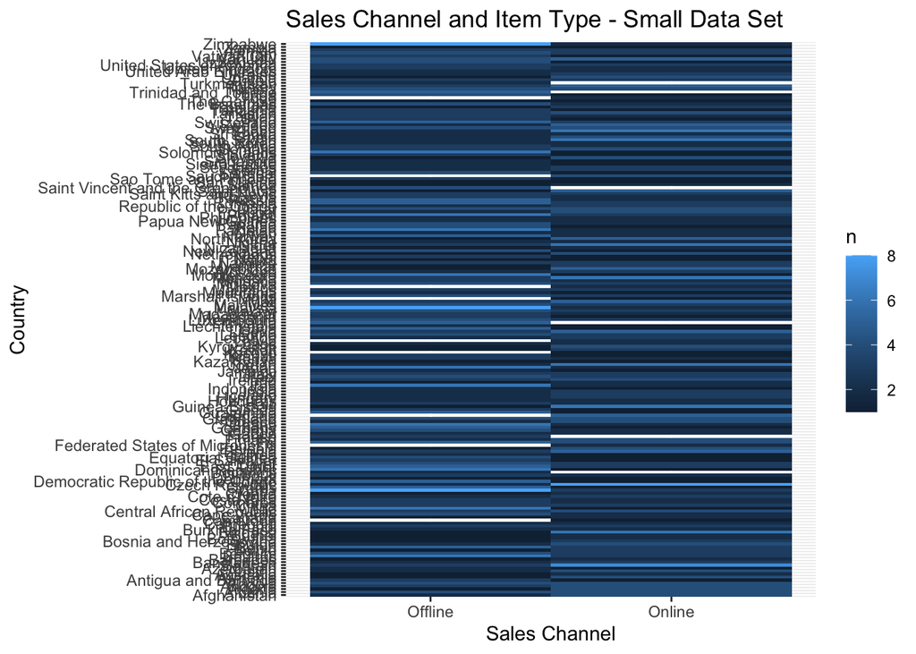

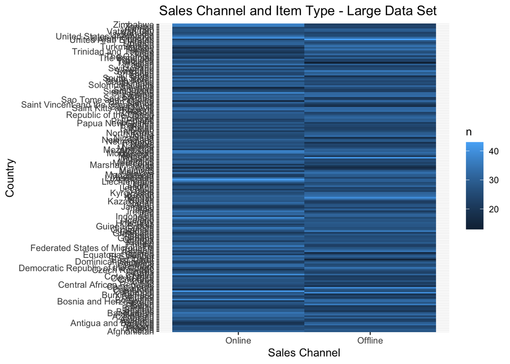

The variation is lower for regions as the horizontal colors do not vary much.

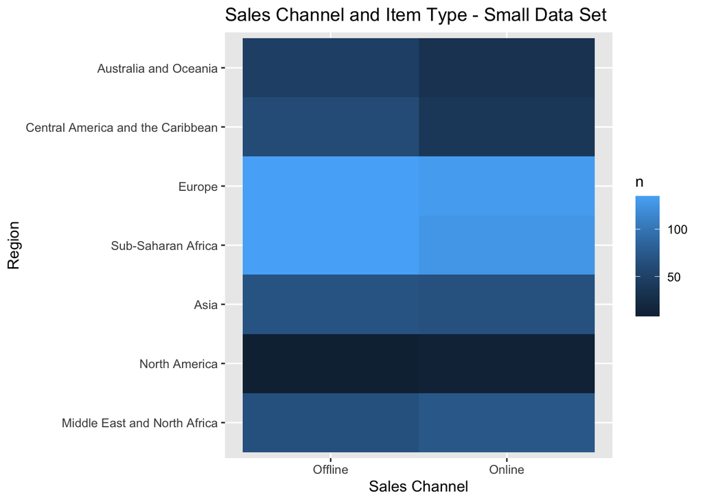

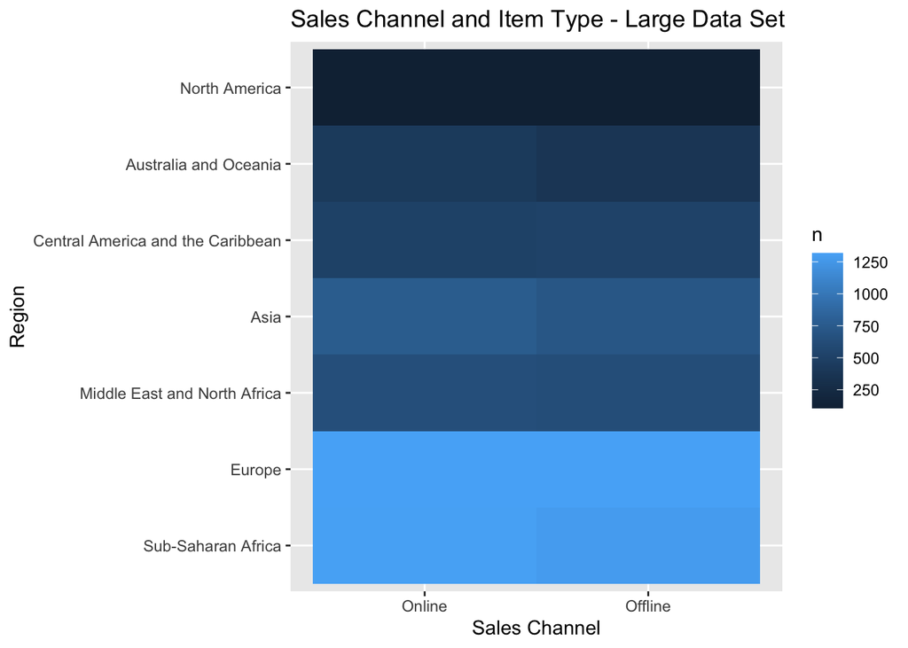

And order priority doesn’t vary a lot either.

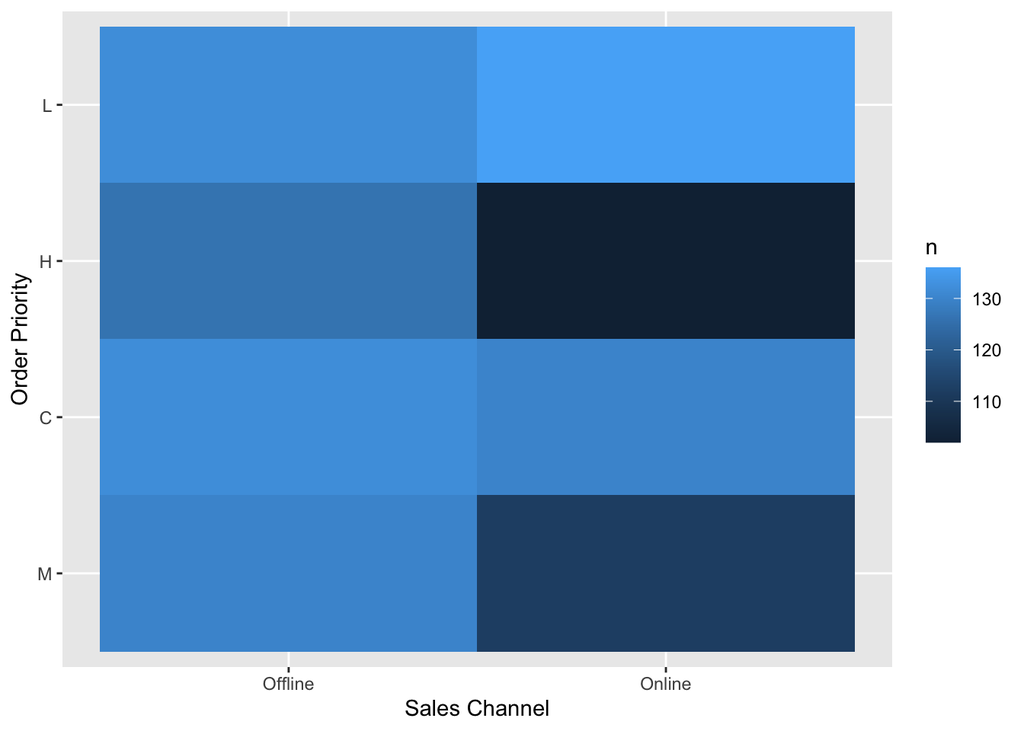

Finally, we check the class balance for the output variable. As both data sets have an even split for both classes, we can consider them to be balanced. This helps by avoiding resampling training sets.

```
##  small..Sales.Channel. large..Sales.Channel.
##  Offline:5200          Online :5061
##  Online :4800          Offline:4939
```

### Continuous Variables

First, just to be sure, we confirm that order ID variable does not repeat.

```r
multiple_order_id <- small %>% group_by(`Order ID`) %>% summarise(total_count=n()) %>% filter(total_count > 1)

if (nrow(multiple_order_id) == 0) {
  paste("All Order IDs are unique")
}
```

```
## [1] "All Order IDs are unique"
```

#### Distributions

There are three types of distributions: uniform; Poisson; undefined. The total-related distributions skew right while the order ID and units sold are uniform. The unit price and unit cost variables appear to be concentrated on lower values (200 and below) but the data is sparse. There distributions appear to be similar for both the large and small data sets.

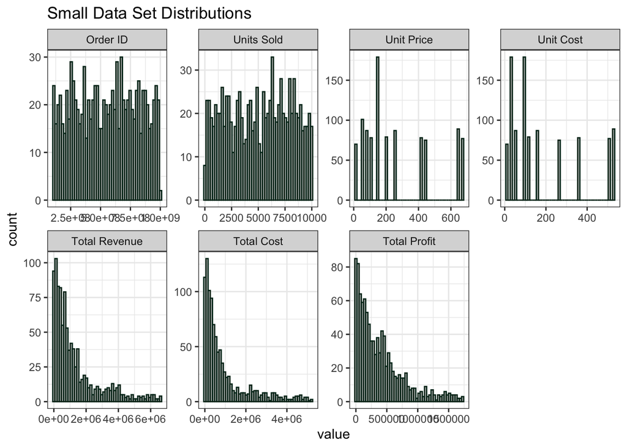

```r
small_numeric <- small %>% dplyr::select(where(is.numeric))
s_df <- small_numeric %>% melt()
s_df %>% ggplot(aes(x= value)) + geom_histogram(color='#023020', fill='gray',bins=50) + facet_wrap(~variable, scales = 'free',  ncol = 4) + theme_bw() + ggtitle("Small Data Set Distributions")
```

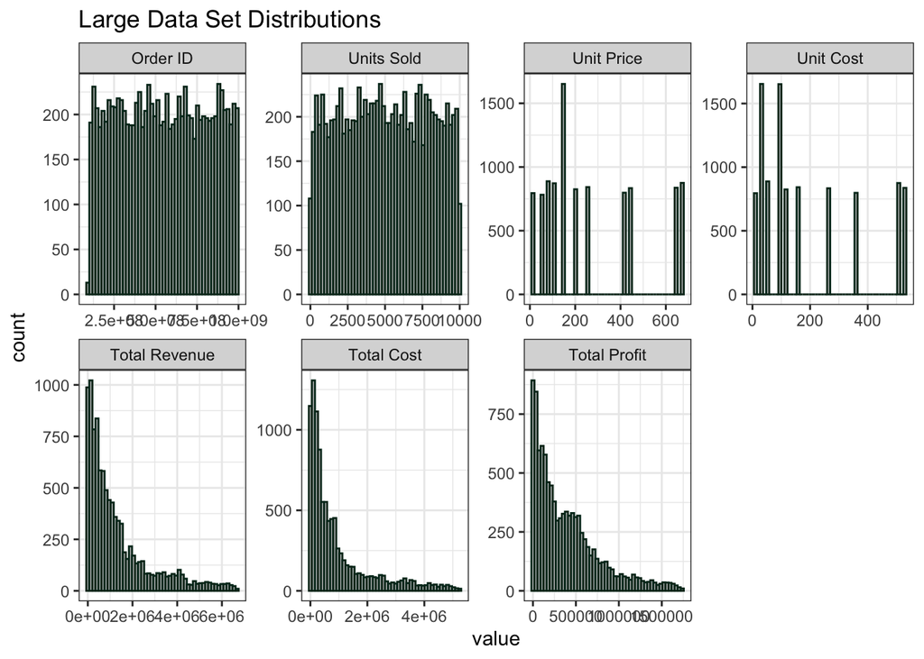

```r
large_numeric <- large %>% dplyr::select(where(is.numeric))
s_df <- large_numeric %>% melt()
s_df %>% ggplot(aes(x= value)) + geom_histogram(color='#023020', fill='gray',bins=50) + facet_wrap(~variable, scales = 'free',  ncol = 4) + theme_bw() + ggtitle("Large Data Set Distributions")
```

#### Scatter plot of numeric variables

Looking at multiple scatter plots, we see there are relationships between unit variables and total variables. This leads me to believe there’s a linear relationship between the relationships along the lines of:

Unit Cost * Units Sold = Total Cost Unit Price * Units Sold = Total Revenue

Total Profit = Total Revenue - Total Cost

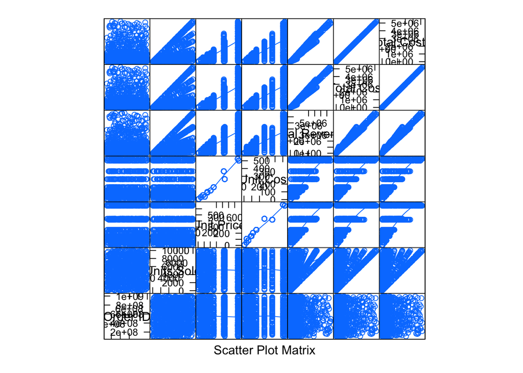

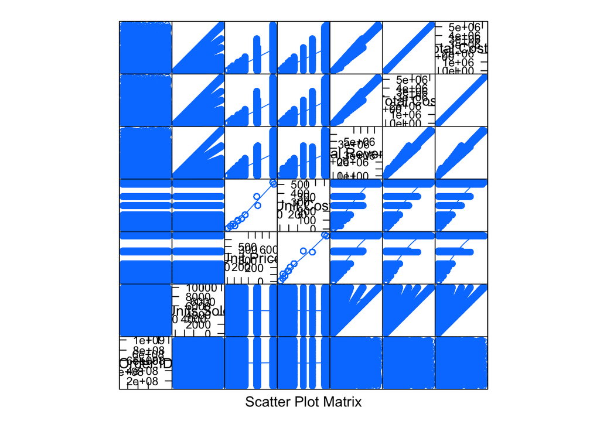

### Colinearity

We see from below some of the variables are collinear. So, in some models, one can be eliminated without any loss of information.

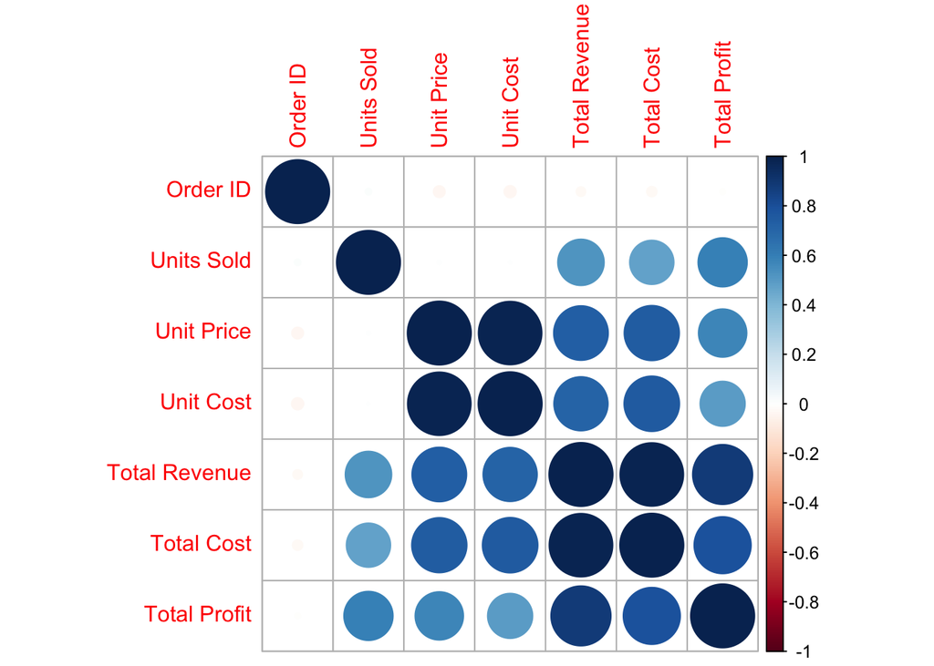

```r
small_correlations <- cor(small_numeric)
corrplot(small_correlations)
```

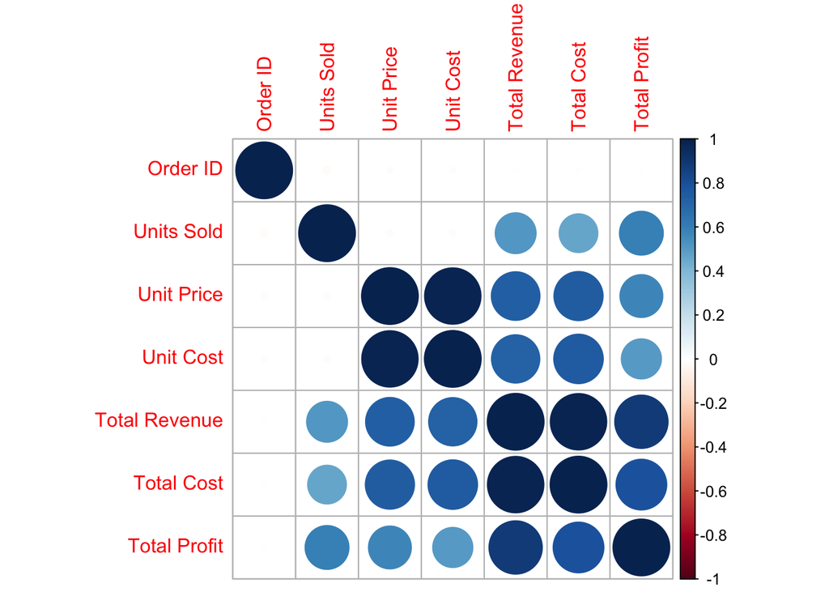

```r
large_correlations <- cor(large_numeric)
corrplot(large_correlations)
```

#### Date Time Normalization

At least one model, requires all continuous variables to be normalized. So, for the date time features, the number of days from an ‘epoch’ date was calculated.

As an experiment, a new feature was created from the two date time objects: a diff_time between the ship and order date.

```r
# choose an epoch date from the earliest date time
start_date <- as.Date(min(small$`Order Date`), "%d/%m/%Y")

# Convert the incoming dates to DateTime objects
small$`Order Date` <- mdy(small$`Order Date`)
small$`Ship Date` <- mdy(small$`Ship Date`)

# Normalize from the epoch date
small$`Ship Date` <- difftime(small$`Ship Date`, start_date, units = "days")
small$`Order Date` <- difftime(small$`Order Date`, start_date, units = "days")

# Add new feature: dates between order and ship
small$`Diff Date` <- small$`Ship Date` - small$`Order Date`

# Cast the dates as numerics
small$`Order Date` <- as.numeric(small$`Order Date`)
small$`Ship Date` <- as.numeric(small$`Ship Date`)
small$`Diff Date` <- as.numeric(small$`Diff Date`)
```

### Differences Between Small & Large Data Sets

From observing the two data sets, it doesn’t appear the larger set has any categories that the smaller does not have. Nor, does the quartiles seem to change very much for the continuous variables, either. Again, neither set has any missing values.

#### Small Data Set Summary - 1,000 Rows

```r
summary(small)
```

```
##                                Region              Country
##  Middle East and North Africa     :138   Cuba          : 11
##  North America                    : 19   Bahrain       : 10
##  Asia                             :136   Czech Republic: 10
##  Sub-Saharan Africa               :262   Malaysia      : 10
##  Europe                           :267   Zimbabwe      : 10
##  Central America and the Caribbean: 99   Belarus       :  9
##  Australia and Oceania            : 79   (Other)       :940
##            Item Type   Sales Channel Order Priority   Order Date
##  Beverages      :101   Offline:520   M:242          Min.   :   0.0
##  Vegetables     : 97   Online :480   C:262          1st Qu.: 682.2
##  Office Supplies: 89                 H:228          Median :1362.5
##  Baby Food      : 87                 L:268          Mean   :1358.0
##  Personal Care  : 87                                3rd Qu.:2009.0
##  Snacks         : 82                                Max.   :2763.0
##  (Other)        :457
##     Order ID           Ship Date      Units Sold     Unit Price
##  Min.   :102928006   Min.   :  14   Min.   :  13   Min.   :  9.33
##  1st Qu.:328074026   1st Qu.: 709   1st Qu.:2420   1st Qu.: 81.73
##  Median :556609714   Median :1380   Median :5184   Median :154.06
##  Mean   :549681325   Mean   :1383   Mean   :5054   Mean   :262.11
##  3rd Qu.:769694483   3rd Qu.:2034   3rd Qu.:7537   3rd Qu.:421.89
##  Max.   :995529830   Max.   :2811   Max.   :9998   Max.   :668.27
##
##    Unit Cost      Total Revenue       Total Cost       Total Profit
##  Min.   :  6.92   Min.   :   2043   Min.   :   1417   Min.   :    532.6
##  1st Qu.: 56.67   1st Qu.: 281192   1st Qu.: 164932   1st Qu.:  98376.1
##  Median : 97.44   Median : 754939   Median : 464726   Median : 277226.0
##  Mean   :184.97   Mean   :1327322   Mean   : 936119   Mean   : 391202.6
##  3rd Qu.:263.33   3rd Qu.:1733503   3rd Qu.:1141750   3rd Qu.: 548456.8
##  Max.   :524.96   Max.   :6617210   Max.   :5204978   Max.   :1726181.4
##
##    Diff Date
##  Min.   : 0
##  1st Qu.:13
##  Median :25
##  Mean   :25
##  3rd Qu.:38
##  Max.   :50
##
```

#### Larget Data Set Summary - 10,0000 Rows

```r
summary(large)
```

```
##                                Region               Country
##  Sub-Saharan Africa               :2603   Lithuania     :  72
##  Europe                           :2633   United Kingdom:  72
##  Middle East and North Africa     :1264   Moldova       :  71
##  Asia                             :1469   Croatia       :  70
##  Central America and the Caribbean:1019   Seychelles    :  70
##  Australia and Oceania            : 797   Botswana      :  69
##  North America                    : 215   (Other)       :9576
##            Item Type    Sales Channel  Order Priority  Order Date
##  Personal Care  : 888   Online :5061   L:2494         Length:10000
##  Household      : 875   Offline:4939   C:2555         Class :character
##  Clothes        : 872                  H:2503         Mode  :character
##  Baby Food      : 842                  M:2448
##  Office Supplies: 837
##  Vegetables     : 836
##  (Other)        :4850
##     Order ID          Ship Date           Units Sold      Unit Price
##  Min.   :100089156   Length:10000       Min.   :    2   Min.   :  9.33
##  1st Qu.:321806669   Class :character   1st Qu.: 2531   1st Qu.:109.28
##  Median :548566305   Mode  :character   Median : 4962   Median :205.70
##  Mean   :549871874                      Mean   : 5003   Mean   :268.14
##  3rd Qu.:775998104                      3rd Qu.: 7472   3rd Qu.:437.20
##  Max.   :999934232                      Max.   :10000   Max.   :668.27
##
##    Unit Cost      Total Revenue       Total Cost       Total Profit
##  Min.   :  6.92   Min.   :    168   Min.   :    125   Min.   :     43.4
##  1st Qu.: 56.67   1st Qu.: 288551   1st Qu.: 164786   1st Qu.:  98329.1
##  Median :117.11   Median : 800051   Median : 481606   Median : 289099.0
##  Mean   :188.81   Mean   :1333355   Mean   : 938266   Mean   : 395089.3
##  3rd Qu.:364.69   3rd Qu.:1819143   3rd Qu.:1183822   3rd Qu.: 566422.7
##  Max.   :524.96   Max.   :6680027   Max.   :5241726   Max.   :1738178.4
##
```

```r
# choose an epoch date from the earliest date time
start_date <- as.Date(min(large$`Order Date`), "%d/%m/%Y")

# Convert the incoming dates to DateTime objects
large$`Order Date` <- mdy(large$`Order Date`)
large$`Ship Date` <- mdy(large$`Ship Date`)

# Normalize from the epoch date
large$`Ship Date` <- difftime(large$`Ship Date`, start_date, units = "days")
large$`Order Date` <- difftime(large$`Order Date`, start_date, units = "days")

# Add new feature: dates between order and ship
large$`Diff Date` <- large$`Ship Date` - large$`Order Date`

# Cast the dates as numerics
large$`Order Date` <- as.numeric(large$`Order Date`)
large$`Ship Date` <- as.numeric(large$`Ship Date`)
large$`Diff Date` <- as.numeric(large$`Diff Date`)
summary(small)
```

```
##                                Region              Country
##  Middle East and North Africa     :138   Cuba          : 11
##  North America                    : 19   Bahrain       : 10
##  Asia                             :136   Czech Republic: 10
##  Sub-Saharan Africa               :262   Malaysia      : 10
##  Europe                           :267   Zimbabwe      : 10
##  Central America and the Caribbean: 99   Belarus       :  9
##  Australia and Oceania            : 79   (Other)       :940
##            Item Type   Sales Channel Order Priority   Order Date
##  Beverages      :101   Offline:520   M:242          Min.   :   0.0
##  Vegetables     : 97   Online :480   C:262          1st Qu.: 682.2
##  Office Supplies: 89                 H:228          Median :1362.5
##  Baby Food      : 87                 L:268          Mean   :1358.0
##  Personal Care  : 87                                3rd Qu.:2009.0
##  Snacks         : 82                                Max.   :2763.0
##  (Other)        :457
##     Order ID           Ship Date      Units Sold     Unit Price
##  Min.   :102928006   Min.   :  14   Min.   :  13   Min.   :  9.33
##  1st Qu.:328074026   1st Qu.: 709   1st Qu.:2420   1st Qu.: 81.73
##  Median :556609714   Median :1380   Median :5184   Median :154.06
##  Mean   :549681325   Mean   :1383   Mean   :5054   Mean   :262.11
##  3rd Qu.:769694483   3rd Qu.:2034   3rd Qu.:7537   3rd Qu.:421.89
##  Max.   :995529830   Max.   :2811   Max.   :9998   Max.   :668.27
##
##    Unit Cost      Total Revenue       Total Cost       Total Profit
##  Min.   :  6.92   Min.   :   2043   Min.   :   1417   Min.   :    532.6
##  1st Qu.: 56.67   1st Qu.: 281192   1st Qu.: 164932   1st Qu.:  98376.1
##  Median : 97.44   Median : 754939   Median : 464726   Median : 277226.0
##  Mean   :184.97   Mean   :1327322   Mean   : 936119   Mean   : 391202.6
##  3rd Qu.:263.33   3rd Qu.:1733503   3rd Qu.:1141750   3rd Qu.: 548456.8
##  Max.   :524.96   Max.   :6617210   Max.   :5204978   Max.   :1726181.4
##
##    Diff Date
##  Min.   : 0
##  1st Qu.:13
##  Median :25
##  Mean   :25
##  3rd Qu.:38
##  Max.   :50
##
```

#### Sampling

For training and test sets, we simply use 75% for training and 25% for testing.

```r
set.seed(12341)
sample_set <- sample(nrow(small), round(nrow(small)*0.75), replace=FALSE)
small_train <- small[sample_set,]
small_test <- small[-sample_set,]

sample_set <- sample(nrow(large), round(nrow(large)*0.75), replace=FALSE)
large_train <- small[sample_set,]
large_test <- small[-sample_set,]
```

### Choosing Two Machine Learning Algorithms

After exploring the data, we can use two different algorithms to predict the sales channel: Naive Bayes and k-nearest neighbors. Again, the sales data set has ten quantitative and five qualitative variables with no missing data. The qualitative variables are pretty well balanced in all cases. However the continuous variables are definitely collinear with outliers and non-normal distributions. But these characteristics fit the two algorithms:

1. KNN - pro’s
1. Makes no assumptions about continuous variable distributions
2. Requires no missing data
3. Qualitative variables should be balanced
4. Fast training
2. KNN - cons’s
1. Requires normalization to handle outliers
2. Classification is slow for larger data sets
3. Naive Bayes - pro’s
1. Fast classification performance
2. Natively processes categorical data very well
3. Handles noisy and missing data
4. Naive Bayes - con’s
1. Does not work well with large numbers of continuous features
2. Assumes all features are independent and equally important

### Balanced Classes

Also, for the country category, all countries should be represented to avoid an error in the prediction (‘cannot predict for rows with new country’). The code below specifically moves rows from the test set to the training set for new countries.

Balancing countries for the smaller set

```r
small_train_country <- small_train %>% dplyr::select(Country)
small_test_country <- small_test %>% dplyr::select(Country)

# balance the countries, some appear a few times in one set.
country_diff <- anti_join(small_test_country, small_train_country)

# we have a data problem here. Some countries only have a count of 1. They should be moved to the training set and out of the test set

country_count <- country_diff %>% group_by(Country) %>% summarise(total_count=n()) %>% arrange(total_count)

single_country_names <- country_count %>% filter (total_count == 1) %>% dplyr::select(Country) %>% as.vector()

# now move them to the training set
small_test_single_countries <- small_test %>% filter(Country %in% single_country_names$Country)

small_train <- rbind(small_train, small_test_single_countries)

# remove them from the test set
small_test <- small_test %>% dplyr::filter(!Country %in% single_country_names$Country)

nrow(small_train)
```

```
## [1] 751
```

```r
nrow(small_test)
```

```
## [1] 249
```

```r
# now sample the other name
multiple_country_names <- country_count %>% filter (total_count > 1) %>% dplyr::select(Country) %>% as.vector()

# Loop through the test countries that have a count > 1
for (country_name in multiple_country_names$Country) {
  # find the rows in test dataframe with this country name
  multiple_country_dataframe <- small_test %>% filter(Country == country_name)

  # sample one...
  multiple_country <- multiple_country_dataframe[sample(nrow(multiple_country_dataframe),1),]

  # and move the one row to the training set
  small_train <- rbind(small_train, multiple_country)
  small_test <- small_test %>% dplyr::filter(`Order ID` != multiple_country$`Order ID`)

  nrow(small_train)
  nrow(small_test)
}
```

Balancing countries for the large set:

```r
large_train_country <- large_train %>% dplyr::select(Country)
large_test_country <- large_test %>% dplyr::select(Country)

# balance the countries, some appear a few times in one set.
country_diff <- anti_join(large_test_country, large_train_country)

# we have a data problem here. Some countries only have a count of 1. They should be moved to the training set and out of the test set

country_count <- country_diff %>% group_by(Country) %>% summarise(total_count=n()) %>% arrange(total_count)

single_country_names <- country_count %>% filter (total_count == 1) %>% dplyr::select(Country) %>% as.vector()

# now move them to the training set
large_test_single_countries <- large_test %>% filter(Country %in% single_country_names$Country)

large_train <- rbind(large_train, large_test_single_countries)

# remove them from the test set
large_test <- large_test %>% dplyr::filter(!Country %in% single_country_names$Country)

nrow(large_train)
```

```
## [1] 7501
```

```r
nrow(large_test)
```

```
## [1] 261
```

```r
# now sample the other name
multiple_country_names <- country_count %>% filter (total_count > 1) %>% dplyr::select(Country) %>% as.vector()

# Loop through the test countries that have a count > 1
for (country_name in multiple_country_names$Country) {
  # find the rows in test dataframe with this country name
  multiple_country_dataframe <- large_test %>% filter(Country == country_name)

  # sample one...
  multiple_country <- multiple_country_dataframe[sample(nrow(multiple_country_dataframe),1),]

  # and move the one row to the training set
  large_train <- rbind(large_train, multiple_country)
  large_test <- large_test %>% dplyr::filter(`Order ID` != multiple_country$`Order ID`)

  nrow(large_train)
  nrow(large_test)
}
```

### Naive Bayes Model

```r
small_train_nb <- small_train #
small_test_nb <- small_test
small_model_nb <- naiveBayes(`Sales Channel` ~ . -`Order ID`-`Ship Date`-`Unit Cost`-`Total Cost`, data=small_train_nb, laplace=1)
small_predict_nb <- predict(small_model_nb, small_test_nb, type="class")
small_table_nb <- table(small_test_nb$`Sales Channel`, small_predict_nb)
paste("Naive Bayes, small data set accuracy: ", round(sum(diag(small_table_nb))/nrow(small_test_nb),2))
```

```
## [1] "Naive Bayes, small data set accuracy:  0.57"
```

```r
#small_model_nb
```

```r
large_train_nb <- large_train #%>% dplyr::select(-c(`Unit Cost`,`Total Cost`,`Order ID`,`Ship Date`,`Diff Date`))
large_test_nb <- large_test #%>% dplyr::select(-c(`Unit Cost`,`Total Cost`,`Order ID`,`Ship Date`,`Diff Date`))
large_model_nb <- naiveBayes(`Sales Channel` ~ . -`Order ID`-`Ship Date`-`Unit Cost`-`Total Cost`, data=large_train_nb, laplace=1)
large_predict_nb <- predict(large_model_nb, large_test_nb, type="class")
large_table_nb <- table(large_test_nb$`Sales Channel`, large_predict_nb)
sum(diag(large_table_nb))/nrow(large_test_nb)
```

```
## [1] 0.4922481
```

```r
paste("Naive Bayes, large data set accuracy: ", round(sum(diag(large_table_nb))/nrow(large_test_nb),2))
```

```
## [1] "Naive Bayes, large data set accuracy:  0.49"
```

```r
#large_model_nb
```

```r
normalize <- function(x) {
  return ((x- min(x)) /( max(x) - min(x)))
}
```

### K-Nearest Neighbor Model

```r
sales_labels <- small %>% dplyr::select(`Sales Channel`)
small_dummies <- dummy_cols(small)
small_dummies <- small_dummies %>%
  mutate(
    `Diff Date` = normalize(as.numeric(`Diff Date`)),
    `Order Date` = normalize(as.numeric(`Order Date`)),
    `Ship Date` = normalize(as.numeric(`Ship Date`)),
    `Order ID` = normalize(as.numeric(`Order ID`)),
    `Units Sold` = normalize(as.numeric(`Units Sold`)),
    `Unit Price` = normalize(as.numeric(`Unit Price`)),
    `Unit Cost` = normalize(as.numeric(`Unit Cost`)),
    `Total Revenue` = normalize(as.numeric(`Total Revenue`)),
    `Total Cost` = normalize(as.numeric(`Total Cost`)),
    `Total Profit` = normalize(as.numeric(`Total Profit`))
    )
sample_dummies_index <- sample(nrow(small_dummies), round(nrow(small_dummies)*0.75), replace=FALSE)
small_train <- small_dummies[sample_dummies_index,]  %>% dplyr::select(-c(Country, Region, `Item Type`,`Sales Channel`, `Sales Channel_Offline`, `Sales Channel_Online`, `Order Priority` ))
small_test <- small_dummies[-sample_dummies_index,]  %>% dplyr::select(-c(Country, Region, `Item Type`,`Sales Channel`, `Sales Channel_Offline`, `Sales Channel_Online`, `Order Priority` ))
small_train_labels <- sales_labels[sample_dummies_index,]
small_test_labels <- sales_labels[-sample_dummies_index,]

knn_accuracies <- c()
best_neighbor <- 1
max_accuracy <- 0
neighbor_range <- 1:10
for (neighbors in neighbor_range) {
  small_knn_pred <- knn(train = small_train, test = small_test, cl = small_train_labels$`Sales Channel`, k=neighbors)
  small_knn_pred_table <- table(small_test_labels$`Sales Channel`, small_knn_pred)
  #knn_accuracy <- sum(diag(small_knn_pred_table))/sum(small_knn_pred_table)
  knn_accuracy <- sum(diag(small_knn_pred_table))/nrow(small_test)

  if (max_accuracy < knn_accuracy) {
      max_accuracy <- knn_accuracy
      best_neighbor <- neighbors
  }
  knn_accuracies <- append(knn_accuracies, knn_accuracy)
}

paste0("Best neighbor:",best_neighbor, ", Accuracy:", max_accuracy )
```

```
## [1] "Best neighbor:5, Accuracy:0.568"
```

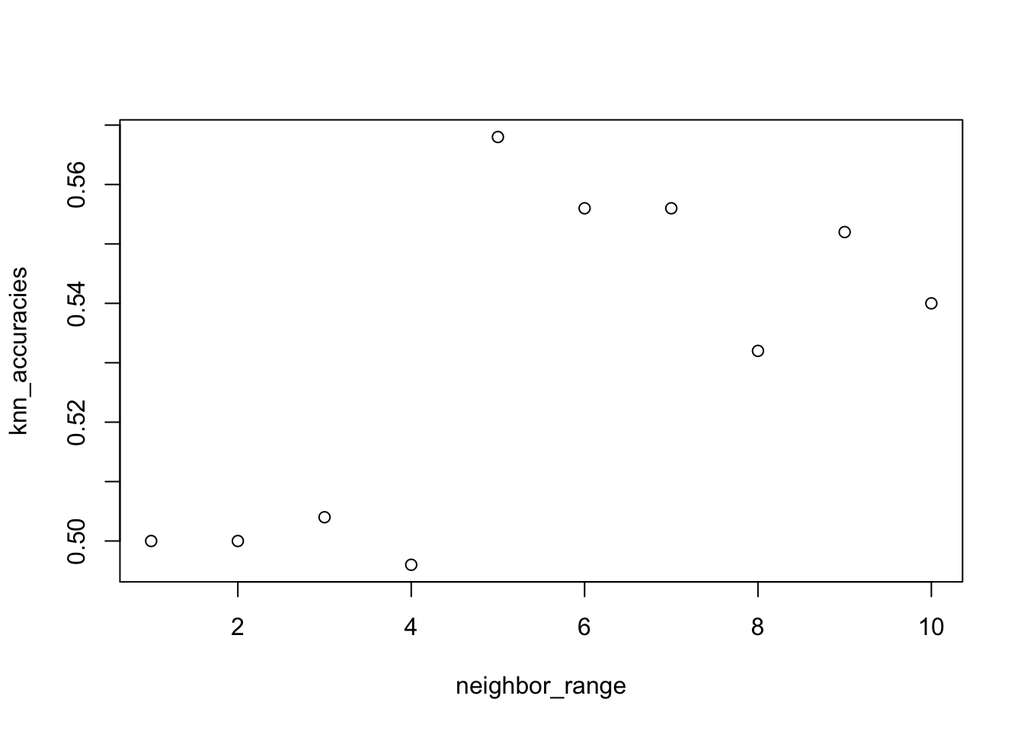

```r
plot(x=neighbor_range, y=knn_accuracies)
```

```r
sales_labels <- large %>% dplyr::select(`Sales Channel`)
large_dummies <- dummy_cols(large)
large_dummies <- large_dummies %>%
  mutate(
    `Diff Date` = normalize(as.numeric(`Diff Date`)),
    `Order Date` = normalize(as.numeric(`Order Date`)),
    `Ship Date` = normalize(as.numeric(`Ship Date`)),
    `Order ID` = normalize(as.numeric(`Order ID`)),
    `Units Sold` = normalize(as.numeric(`Units Sold`)),
    `Unit Price` = normalize(as.numeric(`Unit Price`)),
    `Unit Cost` = normalize(as.numeric(`Unit Cost`)),
    `Total Revenue` = normalize(as.numeric(`Total Revenue`)),
    `Total Cost` = normalize(as.numeric(`Total Cost`)),
    `Total Profit` = normalize(as.numeric(`Total Profit`))
    )
sample_dummies_index <- sample(nrow(large_dummies), round(nrow(large_dummies)*0.75), replace=FALSE)
large_train <- large_dummies[sample_dummies_index,]  %>% dplyr::select(-c(Country, Region, `Item Type`,`Sales Channel`, `Sales Channel_Offline`, `Sales Channel_Online`, `Order Priority` ))
large_test <- large_dummies[-sample_dummies_index,]  %>% dplyr::select(-c(Country, Region, `Item Type`,`Sales Channel`, `Sales Channel_Offline`, `Sales Channel_Online`, `Order Priority` ))
large_train_labels <- sales_labels[sample_dummies_index,]
large_test_labels <- sales_labels[-sample_dummies_index,]

knn_accuracies <- c()
best_neighbor <- 1
max_accuracy <- 0
neighbor_range <- 1:10
for (neighbors in neighbor_range) {
  large_knn_pred <- knn(train = large_train, test = large_test, cl = large_train_labels$`Sales Channel`, k=neighbors)
  large_knn_pred_table <- table(large_test_labels$`Sales Channel`, large_knn_pred)
  #knn_accuracy <- sum(diag(large_knn_pred_table))/sum(large_knn_pred_table)
  knn_accuracy <- sum(diag(large_knn_pred_table))/nrow(large_test)

  if (max_accuracy < knn_accuracy) {
      max_accuracy <- knn_accuracy
      best_neighbor <- neighbors
  }
  knn_accuracies <- append(knn_accuracies, knn_accuracy)
}

paste0("Best neighbor:",best_neighbor, ", Accuracy:", max_accuracy )
```

```
## [1] "Best neighbor:3, Accuracy:0.4988"
```

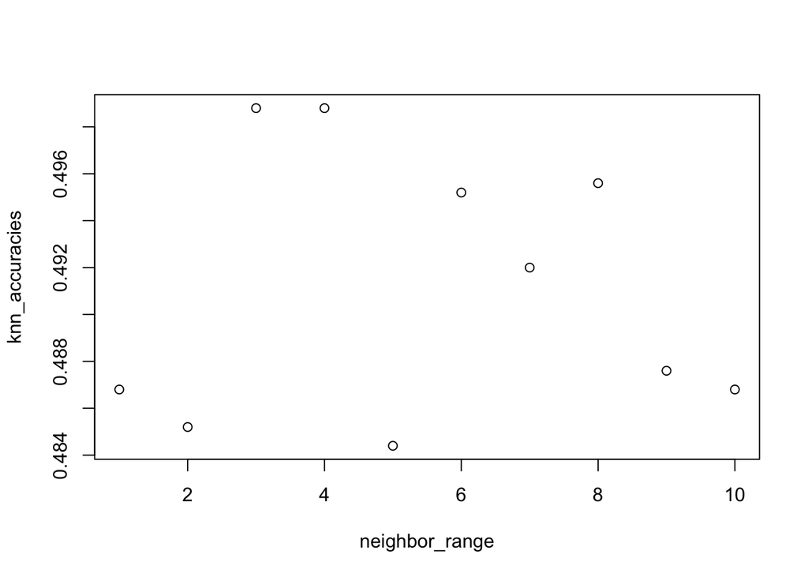

```r
plot(x=neighbor_range, y=knn_accuracies)
```